# Correlation tables for behavioral data and outcomes

Justin Dainer-Best

2017

# Determining optimal parameters of the Self Referent Encoding Task: A large-scale examination of self-referent cognition and depression

This file is one of a series of supplemental explanatory documents for the study “Determining optimal parameters of the Self Referent Encoding Task: A large-scale examination of self-referent cognition and depression”. Data and code are located at [doi: 10.18738/T8/XK5PXX](https://doi.org/10.18738/T8/XK5PXX), and websites with visual R Markdown explanations are located and navigable on the [paper’s github pages website](https://jdbest.github.io/sretmodels/).

## Data description

This code looks at the correlations for the outcome variables of the SRET, for all three samples. If you are viewing this as an HTML file, and wish to see the code, please download the R Markdown file from the [Texas Data Repository](https://doi.org/10.18738/T8/XK5PXX). It includes HTML tables and a graphical expression of correlations using the library `corrplot`.

# Correlation Tables

## UT Sample

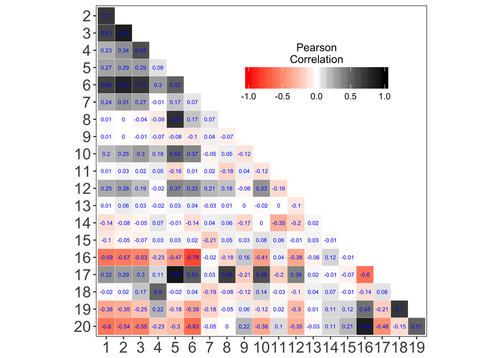

```
 [1] "CES-D"
 [2] "Number of Negative Words Endorsed"
 [3] "Number of Self-Referential Negative Words Recalled"
 [4] "Number of Negative Words Recalled"
 [5] "RT to Negative Words"
 [6] "Drift Rate (v) to Negative Words"
 [7] "Relative Starting Point (zr) for Negative Words"
 [8] "Threshold Separation (a)"
 [9] "Differences in Speed of Response Execution (d)"
[10] "Response Time Constant (t0)"
[11] "Inter-Trial-Variability of Drift (sv)"
[12] "Inter-Trial-Variability of Non-Decisional Components (st0)"
[13] "Percentage of Contaminants (p)"
[14] "Inter-Trial-Variability of Starting Point (szr)"
[15] "Relative Starting Point (zr) for Positive Words"
[16] "Drift Rate (v) to Positive Words"
[17] "RT to Positive Words"
[18] "Number of Positive Words Recalled"
[19] "Number of Self-Referential Positive Words Recalled"
[20] "Number of Positive Words Endorsed"
```

```
** < .001; * < .01; † < .05
```

Variables

1

2

3

4

5

6

7

8

9

10

11

12

13

14

15

16

17

18

19

2. Number of Negative Words Endorsed

0.7**

3. Number of Self-Referential Negative Words Recalled

0.63**

0.85**

4. Number of Negative Words Recalled

0.23†

0.34†

0.59**

5. RT to Negative Words

0.27*

0.29*

0.29†

0.08

6. Drift Rate (v) to Negative Words

0.65**

0.81**

0.71**

0.3†

0.52**

7. Relative Starting Point (zr) for Negative Words

0.24†

0.31†

0.27

-0.01

0.17

0.07

8. Threshold Separation (a)

0.01

0

-0.04

-0.09

0.73**

0.17

0.07

9. Differences in Speed of Response Execution (d)

0.01

0

-0.01

-0.07

-0.08

-0.1

0.04

-0.07

10. Response Time Constant (t0)

0.2*

0.25*

0.3*

0.18

0.52**

0.37**

-0.05

0.05

-0.12†

11. Inter-Trial-Variability of Drift (sv)

0.01

0.03

0.02

0.05

-0.16

0.01

0.02

-0.18†

0.04

-0.12

12. Inter-Trial-Variability of Non-Decisional Components (st0)

0.25*

0.28*

0.19*

-0.02

0.37**

0.33**

0.21

0.18†

-0.06

0.33**

-0.16

13. Percentage of Contaminants (p)

0.01

0.06

0.03

-0.02

0.03

0.04

-0.03

0.01

0

-0.02

0

-0.1

14. Inter-Trial-Variability of Starting Point (szr)

-0.14

-0.08

-0.05

0.07

-0.01

-0.14

0.04

0.06

-0.17

0

-0.35†

-0.2

0.02

15. Relative Starting Point (zr) for Positive Words

-0.1

-0.05

-0.07

0.03

0.03

0.02

-0.21†

0.05

0.03

0.08

0.06

-0.01

0.03

-0.01

16. Drift Rate (v) to Positive Words

-0.59**

-0.57**

-0.53**

-0.23†

-0.47**

-0.78**

-0.02

-0.18

0.16

-0.41**

0.04

-0.38**

-0.06

0.12

-0.01

17. RT to Positive Words

0.32*

0.29*

0.3*

0.11

0.89**

0.53**

0.03

0.66**

-0.21†

0.58**

-0.2

0.39**

0.02

-0.01

-0.07

-0.6**

18. Number of Positive Words Recalled

-0.02

0.02

0.17

0.5*

-0.02

0.04

-0.19

-0.08

-0.12

0.14

-0.03

-0.1

0.04

0.07

-0.01

-0.14

0.08

19. Number of Self-Referential Positive Words Recalled

-0.38**

-0.35**

-0.25*

0.22

-0.18*

-0.39**

-0.18†

-0.05

0.06

-0.12†

0.02

-0.3**

0.01

0.11

0.12

0.45**

-0.21*

0.7*

20. Number of Positive Words Endorsed

-0.6**

-0.54**

-0.55**

-0.23†

-0.3**

-0.63**

-0.05

0

0.22

-0.38**

0.1

-0.35**

-0.03

0.11

0.21

0.84**

-0.48**

-0.15

0.51**

## Mturk Sample

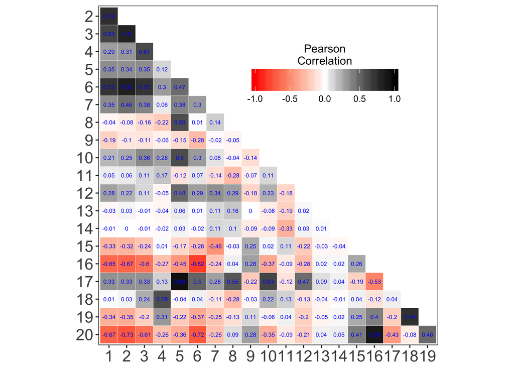

```
 [1] "CES-D"
 [2] "Number of Negative Words Endorsed"
 [3] "Number of Self-Referential Negative Words Recalled"
 [4] "Number of Negative Words Recalled"
 [5] "RT to Negative Words"
 [6] "Drift Rate (v) to Negative Words"
 [7] "Relative Starting Point (zr) for Negative Words"
 [8] "Threshold Separation (a)"
 [9] "Differences in Speed of Response Execution (d)"
[10] "Response Time Constant (t0)"
[11] "Inter-Trial-Variability of Drift (sv)"
[12] "Inter-Trial-Variability of Non-Decisional Components (st0)"
[13] "Percentage of Contaminants (p)"
[14] "Inter-Trial-Variability of Starting Point (szr)"
[15] "Relative Starting Point (zr) for Positive Words"
[16] "Drift Rate (v) to Positive Words"
[17] "RT to Positive Words"
[18] "Number of Positive Words Recalled"
[19] "Number of Self-Referential Positive Words Recalled"
[20] "Number of Positive Words Endorsed"
```

```
** < .001; * < .01; † < .05
```

Variables

1

2

3

4

5

6

7

8

9

10

11

12

13

14

15

16

17

18

19

2. Number of Negative Words Endorsed

0.74**

3. Number of Self-Referential Negative Words Recalled

0.63**

0.8**

4. Number of Negative Words Recalled

0.29†

0.31†

0.61**

5. RT to Negative Words

0.35**

0.34*

0.35*

0.12

6. Drift Rate (v) to Negative Words

0.72**

0.83**

0.72**

0.3†

0.47**

7. Relative Starting Point (zr) for Negative Words

0.35**

0.46**

0.38*

0.06

0.38*

0.3**

8. Threshold Separation (a)

-0.04

-0.08

-0.16

-0.22†

0.59*

0.01

0.14

9. Differences in Speed of Response Execution (d)

-0.19*

-0.1*

-0.11*

-0.06

-0.15*

-0.28*

-0.02†

-0.05

10. Response Time Constant (t0)

0.21*

0.25*

0.36*

0.28†

0.6**

0.3**

0.08

-0.04

-0.14*

11. Inter-Trial-Variability of Drift (sv)

0.05

0.06

0.11

0.17

-0.12

0.07

-0.14

-0.28*

-0.07

0.11

12. Inter-Trial-Variability of Non-Decisional Components (st0)

0.28*

0.22†

0.11

-0.05

0.48**

0.29*

0.34**

0.29†

-0.18*

0.23†

-0.18

13. Percentage of Contaminants (p)

-0.03

0.03

-0.01

-0.04

0.06

0.01

0.11

0.16

0

-0.08

-0.19

0.02

14. Inter-Trial-Variability of Starting Point (szr)

-0.01

0

-0.01

-0.02

0.03

-0.02

0.11

0.1

-0.09

-0.09

-0.33*

0.03

0.01

15. Relative Starting Point (zr) for Positive Words

-0.33**

-0.32**

-0.24**

0.01

-0.17*

-0.28**

-0.46**

-0.03

0.25*

0.02

0.11

-0.22*

-0.03

-0.04

16. Drift Rate (v) to Positive Words

-0.65**

-0.67**

-0.6**

-0.27†

-0.45**

-0.82**

-0.24*

0.04

0.28*

-0.37**

-0.09

-0.28*

0.02

0.02

0.26**

17. RT to Positive Words

0.33**

0.33*

0.33*

0.13

0.94**

0.5**

0.28*

0.55†

-0.22*

0.63**

-0.12

0.47**

0.09

0.04

-0.19*

-0.53**

18. Number of Positive Words Recalled

0.01

0.03

0.24

0.59**

-0.04

0.04

-0.11

-0.28*

-0.03

0.22

0.13

-0.13

-0.04

-0.01

0.04

-0.12

0.04

19. Number of Self-Referential Positive Words Recalled

-0.34**

-0.35**

-0.2*

0.31

-0.22**

-0.37**

-0.25**

-0.13

0.11

-0.06

0.04

-0.2**

-0.05

0.02

0.25*

0.4**

-0.2*

0.74*

20. Number of Positive Words Endorsed

-0.67**

-0.73**

-0.61**

-0.26*

-0.36**

-0.72**

-0.26**

0.09

0.28*

-0.35**

-0.09

-0.21*

0.04

0.05

0.41**

0.88**

-0.43**

-0.08

0.48**

## Adolescent Sample

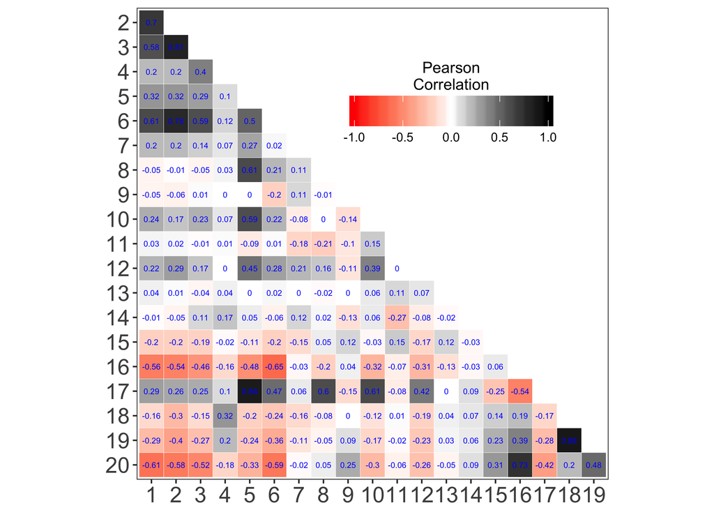

```
 [1] "CDI:S"
 [2] "Number of Negative Words Endorsed"
 [3] "Number of Self-Referential Negative Words Recalled"
 [4] "Number of Negative Words Recalled"
 [5] "RT to Negative Words"
 [6] "Drift Rate (v) to Negative Words"
 [7] "Relative Starting Point (zr) for Negative Words"
 [8] "Threshold Separation (a)"
 [9] "Differences in Speed of Response Execution (d)"
[10] "Response Time Constant (t0)"
[11] "Inter-Trial-Variability of Drift (sv)"
[12] "Inter-Trial-Variability of Non-Decisional Components (st0)"
[13] "Percentage of Contaminants (p)"
[14] "Inter-Trial-Variability of Starting Point (szr)"
[15] "Relative Starting Point (zr) for Positive Words"
[16] "Drift Rate (v) to Positive Words"
[17] "RT to Positive Words"
[18] "Number of Positive Words Recalled"
[19] "Number of Self-Referential Positive Words Recalled"
[20] "Number of Positive Words Endorsed"
```

```
** < .001; * < .01; † < .05
```

Variables

1

2

3

4

5

6

7

8

9

10

11

12

13

14

15

16

17

18

19

2. Number of Negative Words Endorsed

0.7**

3. Number of Self-Referential Negative Words Recalled

0.58**

0.81**

4. Number of Negative Words Recalled

0.2

0.2

0.4†

5. RT to Negative Words

0.32*

0.32*

0.29*

0.1

6. Drift Rate (v) to Negative Words

0.61**

0.78**

0.59**

0.12

0.5**

7. Relative Starting Point (zr) for Negative Words

0.2

0.2

0.14

0.07

0.27

0.02

8. Threshold Separation (a)

-0.05

-0.01

-0.05

0.03

0.61**

0.21

0.11

9. Differences in Speed of Response Execution (d)

-0.05

-0.06

0.01

0

0

-0.2

0.11

-0.01

10. Response Time Constant (t0)

0.24*

0.17†

0.23†

0.07

0.59**

0.22*

-0.08

0

-0.14†

11. Inter-Trial-Variability of Drift (sv)

0.03

0.02

-0.01

0.01

-0.09

0.01

-0.18

-0.21

-0.1

0.15

12. Inter-Trial-Variability of Non-Decisional Components (st0)

0.22*

0.29*

0.17†

0

0.45**

0.28**

0.21

0.16

-0.11

0.39**

0

13. Percentage of Contaminants (p)

0.04

0.01

-0.04

0.04

0

0.02

0

-0.02

0

0.06

0.11

0.07

14. Inter-Trial-Variability of Starting Point (szr)

-0.01

-0.05

0.11

0.17

0.05

-0.06

0.12

0.02

-0.13

0.06

-0.27†

-0.08

-0.02

15. Relative Starting Point (zr) for Positive Words

-0.2*

-0.2*

-0.19*

-0.02

-0.11†

-0.2*

-0.15†

0.05

0.12

-0.03

0.15

-0.17*

0.12

-0.03

16. Drift Rate (v) to Positive Words

-0.56**

-0.54**

-0.46**

-0.16

-0.48**

-0.65**

-0.03

-0.2

0.04

-0.32**

-0.07

-0.31**

-0.13

-0.03

0.06†

17. RT to Positive Words

0.29*

0.26*

0.25*

0.1

0.86**

0.47**

0.06

0.6**

-0.15

0.61**

-0.08

0.42**

0

0.09

-0.25*

-0.54**

18. Number of Positive Words Recalled

-0.16*

-0.3*

-0.15†

0.32

-0.2*

-0.24*

-0.16†

-0.08

0

-0.12†

0.01

-0.19*

0.04

0.07

0.14

0.19*

-0.17*

19. Number of Self-Referential Positive Words Recalled

-0.29**

-0.4**

-0.27**

0.2

-0.24**

-0.36**

-0.11

-0.05

0.09

-0.17*

-0.02

-0.23**

0.03

0.06

0.23†

0.39**

-0.28**

0.88**

20. Number of Positive Words Endorsed

-0.61**

-0.58**

-0.52**

-0.18

-0.33**

-0.59**

-0.02

0.05

0.25

-0.3**

-0.06

-0.26**

-0.05

0.09

0.31*

0.73**

-0.42**

0.2*

0.48**